# **BrainSpan: Expression ratio of CD117 and CD44 according to post conception weeks**

T cell 발달과정에 영향을 끼친다고 알려져 있는 CD molecule인 **CD117**과 **CD44**가 발생 주차 별로 유전자의 발현이 어떻게 달라지는지 알아보고자 합니다.

T cell이 발달할 때 double negative인 경우 CD117과 CD44의 발현이 high하게 나타나고 DN1에서 DN4로 갈수록 그 발현이 줄어든다고 알려져 있습니다. 따라서 시간이 지날수록 CD117과 CD44의 발현이 줄어들것이라 예상할 수 있습니다.

우선 gene 정보가 담겨있는 `g`에 CD117을 검색하면 나오지 않습니다. 다른 이름인 KIT로 검색하여 찾고, 다시 그 `row_num`을 `e`에서 찾아줍니다. CD117에 해당하는 row를 long format으로 바꿔 `s`에 새로운 column으로 지정하여 넣어줍니다. 마찬가지로 CD44에 대해서도 똑같이 진행합니다.

```r
cd117 <- e[10210, ] %>% melt()
s$CD117 <- cd117$value

cd44 <- e[463, ] %>% melt()
s$CD44 <- cd44$value
```

```r
class(s$age)
```

[output not shown]

```r
s$age <- gsub('[^0-9]', '', s$age)
s$age <- as.numeric(s$age)
```

출생 전 data에 한정해서 발현율을 살펴볼 것이기 때문에 age에 pcw가 기입되어있던 column_num 1-17에 해당하는 row data만을 이용합니다. 또한 발생 주차에 따른 CD117/CD44의 expression을 볼 것이므로 x축은 age, y축은 CD117/CD44로 지정합니다.

값의 변화를 눈으로 쉽게 확인하기 위해 `geom_point`와 `geom_line`을 사용하였습니다.

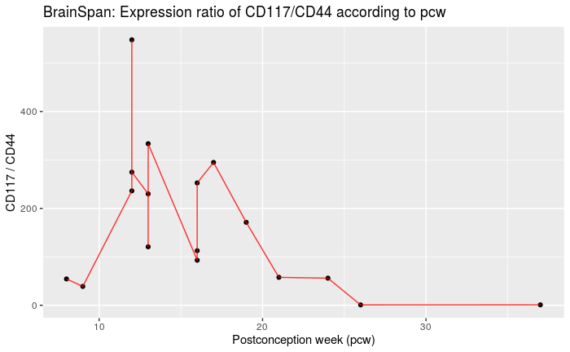

```r
s[1:17,] %>%
  ggplot(aes(age, CD117/CD44)) +
  geom_point() +
  geom_line(stat='identity', color='red', alpha=0.8) +
  xlab("Postconception week (pcw)") +
  ylab("CD117 / CD44") +
  ggtitle("BrainSpan: Expression ratio of CD117/CD44 according to pcw")
```

Plot을 통해 결과적으로 발생 10주차와 20주차 사이에 CD117/CD44의 발현이 증가하는 것을 확인할 수 있으며 이 시기에 T cell development 과정이 활발하게 일어난다고 추측할 수 있습니다.